# Plotting-3

## **0. 2-D plot**

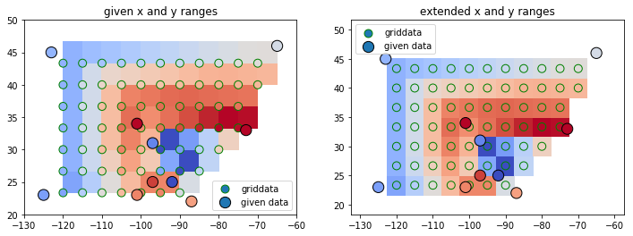

```python
import numpy as np
from scipy.interpolate import griddata
from matplotlib import pyplot as plt
%matplotlib inline

def extend_range(x):
    dx = (x[1] - x[0]) / 2
    return np.append( x - dx, x[-1] + dx)

N = 10
points1 = np.vstack([np.random.randint(-130, -60, N), np.random.randint(20, 50, N)]).T
tempratio = np.random.randint(0, 20, N)

xg = np.linspace(-130, -60, num=15)
yg = np.linspace(20, 50, num=10)
Xg, Yg = np.meshgrid(xg, yg)

zg1 = griddata(points1, tempratio, (Xg, Yg), method='linear')

fig, axs = plt.subplots(ncols=2, figsize=(12, 4))
for ax in axs:
    ax.scatter(Xg, Yg, c=zg1, cmap='coolwarm',  edgecolors='g', s=80, zorder=2, label='griddata')
    ax.scatter(points1[:,0], points1[:,1], c=tempratio, cmap='coolwarm', edgecolors='black', s=150, zorder=3, label='given data')

    if ax == axs[0]:
        ax.pcolormesh(xg, yg, zg1, shading='flat', cmap='coolwarm')
        ax.set_title('given x and y ranges')
    else:
        #todo: convert xg and yg to map coordinates
        ax.pcolormesh(extend_range(xg), extend_range(yg), zg1, shading='flat', cmap='coolwarm')
        ax.set_title('extended x and y ranges')
    ax.legend()
plt.show()
```

```python
 points1
```

```
array([[ -65,   46],
       [-123,   45],
       [-101,   23],
       [ -87,   22],
       [-101,   34],
       [ -92,   25],
       [-125,   23],
       [ -97,   25],
       [ -97,   31],
       [ -73,   33]])
```

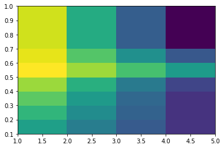

```python
import numpy as np
import scipy.interpolate as interp
import matplotlib.pyplot as plt
%matplotlib inline


# input
xv = np.array([1, 3, 5])
yv = np.array([0.1, 0.4, 0.5, 0.7])
x,y = np.meshgrid(xv,yv)
M = np.random.rand(4,3)

xqv = np.arange(1,6)
yqv = np.arange(0.1,1.1,0.1)
xq,yq = np.meshgrid(xqv,yqv)
zqfun = interp.interp2d(x,y,M)
zq = zqfun(xqv,yqv)

plt.figure()
h = plt.pcolor(xq,yq,zq)
#h = plt.pcolormesh(xq,yq,zq)   # <-- same thing but faster
```

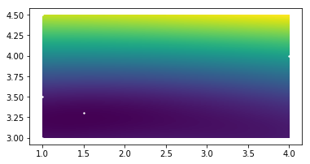

```python
import numpy as np
from scipy.interpolate import Rbf
%matplotlib inline
import matplotlib.pyplot as plt

data = {(1,3):22, (1,3.5):23, (1,4.5):25, (1.5,3.3):19, (4,4):100}

# Extract the data.
x = np.array([k[0] for k in data.keys()])
y = np.array([k[1] for k in data.keys()])
z = np.array([v for v in data.values()])

# Make the grid.
minx, maxx = np.amin(x), np.amax(x)
miny, maxy = np.amin(y), np.amax(y)
extent = (minx, maxx, miny, maxy)
grid_x, grid_y = np.mgrid[minx:maxx:0.01, miny:maxy:0.01]

# Make an n-dimensional interpolator.
rbfi = Rbf(x, y, z)

# Predict on the regular grid.
z_ = rbfi(grid_x, grid_y)

# Look at it!
plt.imshow(z_, origin="lower", extent=extent)
plt.scatter(x, y, s=2, c='w')
```

```python
N =10
points1 = np.vstack([np.random.randint(-130, -60, N), np.random.randint(20, 50, N)]).T
np.vstack([np.random.randint(-130, -60, N), np.random.randint(20, 50, N)])
```

```
array([[ -79,  -72,  -98, -117, -113,  -78,  -74,  -77, -123,  -72],
       [  49,   43,   20,   39,   29,   42,   43,   26,   36,   25]])
```

## **1. 3-D plot**

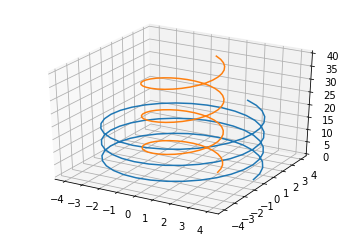

```python
import numpy as np
import matplotlib.pyplot as plt
from mpl_toolkits.mplot3d import Axes3D
%matplotlib inline
def spiral(a, b, t):
    x = a * np.cos(t)
    y = a * np.sin(t)
    z = b * t
    return x, y, z

t = np.linspace(0, 20, 100)
x1, y1, z1 = spiral(4, 1, t)
x2, y2, z2 = spiral(2, 2, t)

fig = plt.figure()
ax = fig.add_subplot(111, projection='3d')
ax.plot(x1, y1, z1)
ax.plot(x2, y2, z2);
```

### **3-D surface plot**

help('mpl_toolkits.mplot3d.axes3d.Axes3D.plot_surface')

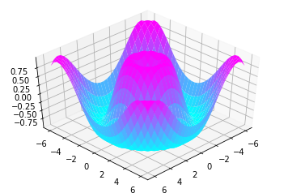

```python
import numpy as np
import matplotlib.pyplot as plt
import matplotlib.cm as cm
from mpl_toolkits.mplot3d import Axes3D

def func(x, y):
    z = np.sin(np.sqrt(x ** 2 + y ** 2))
    return z

x = np.linspace(-6, 6, 30)
y = np.linspace(-6, 6, 30)
X, Y = np.meshgrid(x, y)
Z = func(X, Y)

fig = plt.figure()
ax = fig.add_subplot(111, projection='3d')
ax.plot_surface(X, Y, Z, cmap=cm.cool)
ax.view_init(45, 45)
```

#### **Exercise: Plotting Torus**

In geometry, a torus is a surface of revolution generated by revolving a circle in three-dimensional space about an axis that is coplanar with the circle.

在几何学中，圆环是通过使圆在三维空间中绕与圆共面的轴旋转而生成的旋转表面。

```
(-3, 3)
```

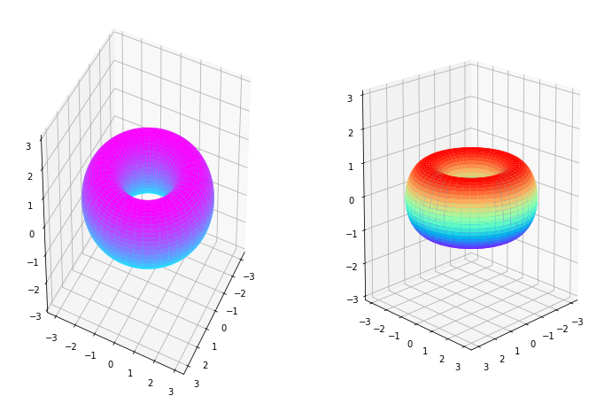

```python
# importing modules
import matplotlib.pyplot as plt
import numpy as np
import matplotlib.cm as cm
# defining function
def torus(r, R, theta, phi):
    x = (R + r*np.cos(theta))*np.cos(phi)
    y = (R + r*np.cos(theta))*np.sin(phi)
    z = r*np.sin(theta)
    return x,y,z

# initializing values of arrays
r = 1
R = 2
angle =  np.linspace(0, 2*np.pi, 100)
theta, phi = np.meshgrid(angle, angle)
x, y, z = torus(r, R, theta, phi)

# initializing figure
fig = plt.figure(figsize = (12, 8))
ax1 = fig.add_subplot(121, projection = '3d')
# plotting commands for first plot
ax1.plot_surface(x, y, z, cmap =cm.cool)
ax1.view_init(36, 26)
ax1.set_zlim(-3, 3)

# plotting commands for second plot
ax2 = fig.add_subplot(122, projection = '3d')
# plotting commands for first plot
ax2.plot_surface(x, y, z, cmap =cm.rainbow)
ax2.view_init(15, 45)
ax2.set_zlim(-3, 3)

# plot saving command
#plt.savefig('output/torus.png')
```

```python
def torus(a, b,c ):
    x = a + b + c
    y = a +10*b +c
    z = a*b +c
    return [x,y,z]
[x,y,z] = torus(5,3,1)
print(x)
print()
print(y)
print()
print(z)
```

```
9

36

16
```

## **2. Gallery of graphs**

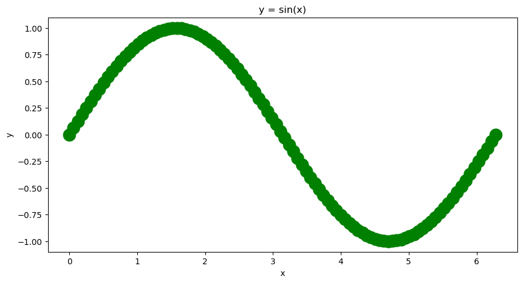

```python
import numpy as np
import matplotlib.pyplot as plt
%matplotlib inline

x = np.linspace(0, 2 *np.pi, 100)
y = np.sin(x)
fig = plt.figure(figsize=(10, 5), dpi=100)
ax1 = fig.add_axes([0.1, 0.1, 0.8, 0.8])      #add_axes([bottom x, bottom y, width, height])
#ax1.plot(x, y, 'b')
ax1.plot(x, y, color='g', marker='o', linestyle='-', linewidth=4, markersize=15)
ax1.set_xlabel('x')
ax1.set_ylabel('y')
ax1.set_title('y = sin(x)');
```

1. `figsize` is a tuple of the width and height of the figure in inches.
2. In the example above, we create a 10x5 unit figure and since the resolution (dpi) is 100, this translates to 1000 x 500 pixels.
3. `help("matplotlib.pyplot.plot")` to get the full options

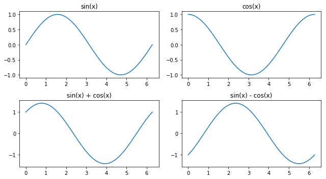

```python
import numpy as np
import matplotlib.pyplot as plt

x = np.linspace(0, 2 * np.pi , 100)
y1 = np.sin(x)
y2 = np.cos(x)

fig, ax = plt.subplots(2, 2, figsize=(9, 5)) # creates a 2x2 grid

ax[0, 0].plot(x, y1) # plots on [0, 0] block on the grid
ax[0, 0].set_title("sin(x)")

ax[0, 1].plot(x, y2) # plots on the [0, 1] block on the grid
ax[0, 1].set_title("cos(x)")

ax[1, 0].plot(x, y1 + y2) # plots on [1, 0] block on the grid
ax[1, 0].set_title("sin(x) + cos(x)")

ax[1, 1].plot(x, y1 - y2) # plots on the [1, 1] block on the grid
ax[1, 1].set_title("sin(x) - cos(x)")

fig.tight_layout()
```

##### **Ticks**

```
[Text(0,0,'0'),
 Text(0,0,'$0.5\\pi$'),
 Text(0,0,'$\\pi$'),
 Text(0,0,'$1.5\\pi$'),
 Text(0,0,'$2\\pi$')]
```

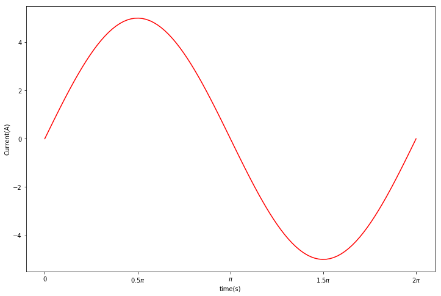

```python
import numpy as np
import matplotlib.pyplot as plt

t = np.linspace(0, 2 * np.pi, 100)
I = 5 * np.sin(t)

fig, axes = plt.subplots(figsize=(12, 8))

axes.plot(t, I, 'r')
axes.set_xlabel("time(s)")
axes.set_ylabel("Current(A)")

axes.set_xticks(np.linspace(0, 2 * np.pi, 5)) # specifying ticks
axes.set_xticklabels(['0', r'$0.5\pi$', r'$\pi$', r'$1.5\pi$', r'$2\pi$' ]) # custom ticks
```

##### **Twin axis**

[output not shown]

```
Text(0,0.5,'Voltage(V)')
```

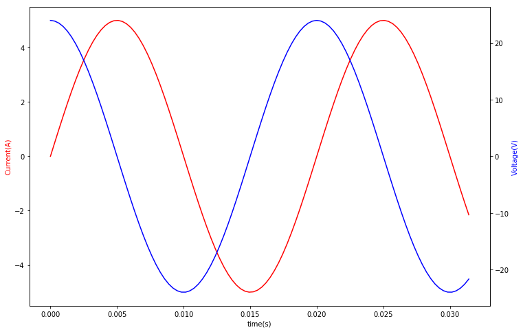

```python
import numpy as np
import matplotlib.pyplot as plt

t = np.linspace(0, np.pi/100, 100)    # an array of time
print(t)
W = 2 * np.pi * 50             # angular frequency
theta = np.pi/2    # phase difference

I = 5 * np.sin(W * t)   # values of current
V = 24 * np.sin(W * t + theta)   # values of voltage

fig, axesI = plt.subplots(figsize=(12, 8))

axesI.plot(t, I, 'r')
axesI.set_xlabel("time(s)")
axesI.set_ylabel("Current(A)", color='red')

axesV = axesI.twinx()  # instantiate a second axes that shares the same x-axis

axesV.plot(t, V, 'b')
axesV.set_ylabel("Voltage(V)", color='blue')
```

##### **axis spines**

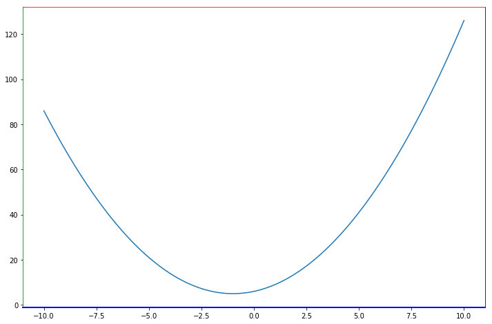

```python
import numpy as np
import matplotlib.pyplot as plt

x = np.linspace(-10, 10, 100)
y = x**2 + (2 * x) + 6

fig, axes = plt.subplots(figsize=(12, 8))
axes.spines['top'].set_color('r')   # setting color of top spine
axes.spines['bottom'].set_color('b')    # setting color of bottom spine
axes.spines['bottom'].set_linewidth(2)  # setting linewidth of bottom spine
axes.spines['left'].set_color('g')     # setting color of left spine
axes.plot(x, y)
```

### **Pie Charts**

[output not shown]

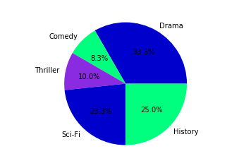

```python
import numpy as np
import matplotlib.pyplot as plt

genre = ['Drama', 'Comedy', 'Thriller', 'Sci-Fi', 'History']
amount = [100, 25, 30, 70, 75]
pieColor = ['MediumBlue', 'SpringGreen', 'BlueViolet'];

plt.axis('equal')
plt.pie(amount, labels=genre, autopct='%1.1f%%', colors=pieColor)
```

### **Histograms**

```
(-4.517885724532704, 3.972723805454249)
```

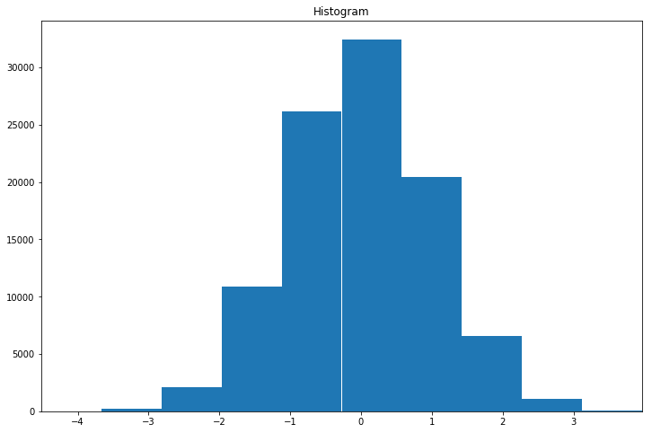

```python
import numpy as np
import matplotlib.pyplot as plt

n = np.random.randn(100000)
fig, axes = plt.subplots(figsize=(12, 8))
plt.hist(n)
axes.set_title("Histogram")
axes.set_xlim((min(n), max(n)))
```

### **Bar graphs**

```
Text(0.5,1,'Bar Chart')
```

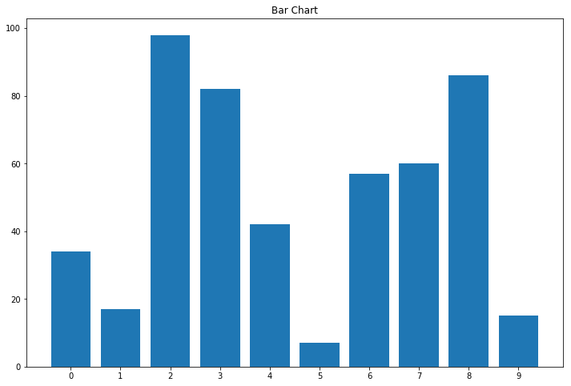

```python
import numpy as np
import matplotlib.pyplot as plt

y = np.random.randint(low=1, high=100, size=10)
x = np.arange(10)
fig, axes = plt.subplots(figsize=(12, 8))
axes.bar(x, y)
axes.set_xticks(np.arange(10))
axes.set_title("Bar Chart")
```

### **Box plot**

A boxplot presents information from a five-number summary. It does not show the distribution in as much detail but is useful for indicating whether a distribution is skewed and whether there are unusual observations in the data set. Boxplots are very useful when large numbers of observations are involved and two or more data sets are being compared.

箱形图显示了五位数摘要中的信息。它没有详细显示分布，但对于指示分布是否偏斜以及数据集中是否存在异常观察很有用。当涉及大量观察并且正在比较两个或更多数据集时，箱线图非常有用。

```
Text(0.5,1,'Box Plot')
```

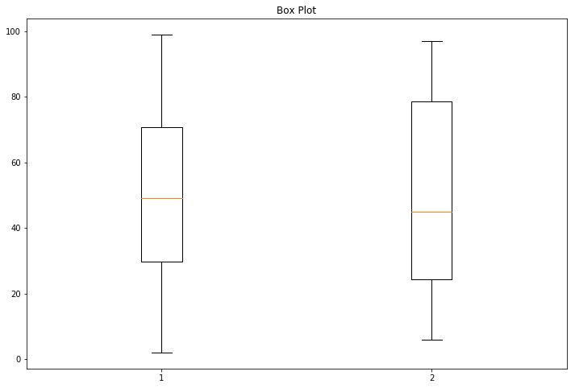

```python
import numpy as np
import matplotlib.pyplot as plt

data1 = np.random.randint(low=1, high=100, size=50)
data2 = np.random.randint(low=1, high=100, size=50)
data = [data1, data2]
fig, axes = plt.subplots(figsize=(12, 8))

axes.boxplot(data)
axes.set_title("Box Plot")
```

### **Polar plot**

[figure not shown]

```python
import numpy as np
import matplotlib.pyplot as plt

theta = np.linspace(0, 2 * np.pi , 100)
r = np.sin(50 * theta) * np.cos(50 * theta)
fig = plt.figure()
ax = fig.add_subplot(111, polar=True)
ax.plot(theta, r);
```

### **Fill between**

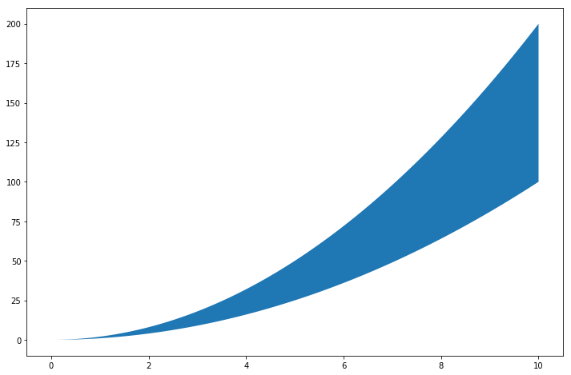

```python
import numpy as np
import matplotlib.pyplot as plt

x = np.linspace(0, 10, 100)
fig, axes = plt.subplots(figsize=(12, 8))
axes.fill_between(x, 2 * x**2, x**2)
```

### **Scatter**

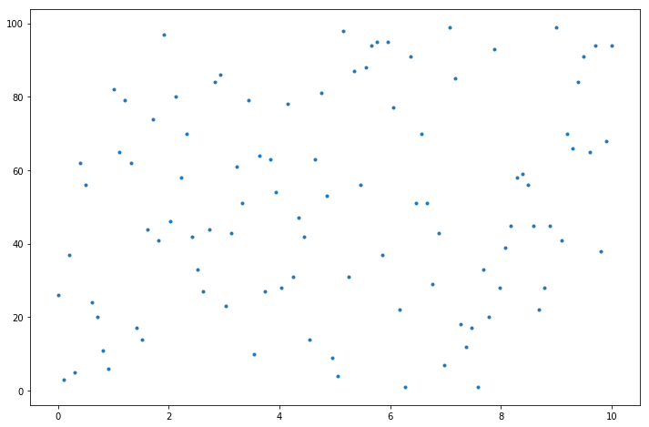

```python
import numpy as np
import matplotlib.pyplot as plt

x = np.linspace(0, 10, 100)
y = np.random.randint(low=1, high=100, size=100)    # creates a random array of 100 intergers
                                                    # ranging from 1 - 100
fig, axes = plt.subplots(figsize=(12, 8))
axes.scatter(x, y, marker='.')
```

#### **Exercise: Plotting temperatures**

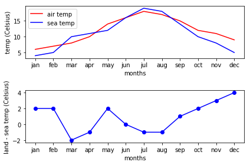

```python
import numpy as np
import matplotlib.pyplot as plt

land_temp = np.array([6, 7, 8, 10, 14, 16, 18, 17, 15, 12, 11, 9])
sea_temp = np.array([4, 5, 10, 11, 12, 16, 19, 18, 14, 10, 8, 5])

fig, ax = plt.subplots(2, 1)
ticks = ['jan','feb','mar','apr','may','jun','jul','aug','sep','oct','nov','dec']

x = np.linspace(0, 13, 12)
# commands for plotting the first graph
ax[0].plot(x, land_temp, 'r', label = 'air temp')
ax[0].plot(x, sea_temp, 'b', label = 'sea temp')
ax[0].set_xticks(x)
ax[0].set_xticklabels(ticks)
ax[0].legend(loc = 'best')
ax[0].set_ylabel('temp (Celsius)')
ax[0].set_xlabel('months')

# commands for plotting the second graph
ax[1].plot(x, land_temp - sea_temp, 'b-o')
ax[1].set_xticks(x)
ax[1].set_xticklabels(ticks)
ax[1].set_ylabel('land - sea temp (Celsius)')
ax[1].set_xlabel('months')

# to prevent overlap in plots
fig.tight_layout()

# saving the figure
# fig.savefig('output/out.png')
```